# Подготовка к работе

К содержанию

Загрузим все необходимые для работы библиотеки

```python
import pandas as pd
import matplotlib.pyplot as plt
from scipy import stats as st
import numpy as np
import datetime as dt
from pandas.plotting import register_matplotlib_converters
import warnings
```

# Описание

К содержанию

В данной работе наша цель - помочь крупному интернет-магазину увеличить выручку. В исполнении этой задачи нам поможет отдел маркетитнга.

Для достижения этой цели перед нами стоят следующие задачи:

1. Определить наиболее "удачные" гипотезы для проверки
2. Провести А/В тест
3. Проанализировать полученные результаты

Перейдем к выполнению поставленных задач.

## Подготовка данных

К содержанию

Перед тем, как приступить к анализу бизнес-показателей проанализируем наши данные, чтобы избежать ошибок из-за пропусков или некорретных типов данных.

### Загрузка таблиц

К содержанию

```python
path = 'D:\\Irina\\datasets\\'
hypothesis = pd.read_csv(path + 'hypothesis.csv')
orders = pd.read_csv(path + 'orders.csv')
visitors = pd.read_csv(path + 'visitors.csv')
pd.options.display.max_colwidth = 100

display(hypothesis, orders.head(), visitors.head())
```

|  | Hypothesis | Reach | Impact | Confidence | Efforts |
| --- | --- | --- | --- | --- | --- |
| 0 | Добавить два новых канала привлечения трафика, что позволит привлекать на 30% больше пользователей | 3 | 10 | 8 | 6 |
| 1 | Запустить собственную службу доставки, что сократит срок доставки заказов | 2 | 5 | 4 | 10 |
| 2 | Добавить блоки рекомендаций товаров на сайт интернет магазина, чтобы повысить конверсию и средни... | 8 | 3 | 7 | 3 |
| 3 | Изменить структура категорий, что увеличит конверсию, т.к. пользователи быстрее найдут нужный товар | 8 | 3 | 3 | 8 |
| 4 | Изменить цвет фона главной страницы, чтобы увеличить вовлеченность пользователей | 3 | 1 | 1 | 1 |
| 5 | Добавить страницу отзывов клиентов о магазине, что позволит увеличить количество заказов | 3 | 2 | 2 | 3 |
| 6 | Показать на главной странице баннеры с актуальными акциями и распродажами, чтобы увеличить конве... | 5 | 3 | 8 | 3 |
| 7 | Добавить форму подписки на все основные страницы, чтобы собрать базу клиентов для email-рассылок | 10 | 7 | 8 | 5 |
| 8 | Запустить акцию, дающую скидку на товар в день рождения | 1 | 9 | 9 | 5 |

|  | transactionId | visitorId | date | revenue | group |
| --- | --- | --- | --- | --- | --- |
| 0 | 3667963787 | 3312258926 | 2019-08-15 | 1650 | B |
| 1 | 2804400009 | 3642806036 | 2019-08-15 | 730 | B |
| 2 | 2961555356 | 4069496402 | 2019-08-15 | 400 | A |
| 3 | 3797467345 | 1196621759 | 2019-08-15 | 9759 | B |
| 4 | 2282983706 | 2322279887 | 2019-08-15 | 2308 | B |

|  | date | group | visitors |
| --- | --- | --- | --- |
| 0 | 2019-08-01 | A | 719 |
| 1 | 2019-08-02 | A | 619 |
| 2 | 2019-08-03 | A | 507 |
| 3 | 2019-08-04 | A | 717 |
| 4 | 2019-08-05 | A | 756 |

Итак, у нас есть три таблицы:

1. `hypothesis` - содержит выдвинутые гипотезы и их показатели:
   - Hypothesis — краткое описание гипотезы;
   - Reach — охват пользователей по 10-балльной шкале;
   - Impact — влияние на пользователей по 10-балльной шкале;
   - Confidence — уверенность в гипотезе по 10-балльной шкале;
   - Efforts — затраты ресурсов на проверку гипотезы по 10-балльной шкале. Чем больше значение Efforts, тем дороже проверка гипотезы.
2. `orders` - содержит данные о произведенных заказах:
   - transactionId — идентификатор заказа;
   - visitorId — идентификатор пользователя, совершившего заказ;
   - date — дата, когда был совершён заказ;
   - revenue — выручка заказа;
   - group — группа A/B-теста, в которую попал заказ.
3. `visits` - содержит данные о посещениях сайта:
   - date — дата;
   - group — группа A/B-теста;
   - visitors — количество пользователей в указанную дату в указанной группе A/B-теста.

Теперь проанализируем данные, содержащиеся в этих таблицах.

### Получение информации о данных

К содержанию

```python
print(hypothesis.info(), orders.info(), visitors.info())
```

```
<class 'pandas.core.frame.DataFrame'>
RangeIndex: 9 entries, 0 to 8
Data columns (total 5 columns):
 #   Column      Non-Null Count  Dtype
---  ------      --------------  -----
 0   Hypothesis  9 non-null      object
 1   Reach       9 non-null      int64
 2   Impact      9 non-null      int64
 3   Confidence  9 non-null      int64
 4   Efforts     9 non-null      int64
dtypes: int64(4), object(1)
memory usage: 492.0+ bytes
<class 'pandas.core.frame.DataFrame'>
RangeIndex: 1197 entries, 0 to 1196
Data columns (total 5 columns):
 #   Column         Non-Null Count  Dtype
---  ------         --------------  -----
 0   transactionId  1197 non-null   int64
 1   visitorId      1197 non-null   int64
 2   date           1197 non-null   object
 3   revenue        1197 non-null   int64
 4   group          1197 non-null   object
dtypes: int64(3), object(2)
memory usage: 46.9+ KB
<class 'pandas.core.frame.DataFrame'>
RangeIndex: 62 entries, 0 to 61
Data columns (total 3 columns):
 #   Column    Non-Null Count  Dtype
---  ------    --------------  -----
 0   date      62 non-null     object
 1   group     62 non-null     object
 2   visitors  62 non-null     int64
dtypes: int64(1), object(2)
memory usage: 1.6+ KB
None None None
```

На первый взгляд в таблицах нет пропусков. Но есть другая проблема - даты в таблицах `orders` и `visits` представлены текстовым типом данных. Так что следует заняться предобработкой.

### Предобработка данных

К содержанию

Проверим, есть ли пропуски в данных, дубликаты и исправим несостыковки в типах данных.

#### Пропуски

К содержанию

```python
print('Количество пропусков в таблице hypothesis:')
print(hypothesis.isna().sum())
print('Количество пропусков в таблице orders:')
print(orders.isna().sum())
print('Количество пропусков в таблице visitors:')
print(visitors.isna().sum())
```

```
Количество пропусков в таблице hypothesis:
Hypothesis    0
Reach         0
Impact        0
Confidence    0
Efforts       0
dtype: int64
Количество пропусков в таблице orders:
transactionId    0
visitorId        0
date             0
revenue          0
group            0
dtype: int64
Количество пропусков в таблице visitors:
date        0
group       0
visitors    0
dtype: int64
```

Ну что же, пропусков действительно нет.

#### Дубликаты

К содержанию

```python
print('Количество явных дубликатов в таблице hypothesis:', hypothesis.duplicated().sum(),
      '\nКоличество явных дубликатов в таблице orders:', orders.duplicated().sum(),
      '\nКоличество явных дубликатов в таблице visitors:', visitors.duplicated().sum())
```

```
Количество явных дубликатов в таблице hypothesis: 0
Количество явных дубликатов в таблице orders: 0
Количество явных дубликатов в таблице visitors: 0
```

Явных дубликатов также нет, неявные дубликаты в данном случае проверить трудно, поэтому предположим, что их нет.

#### Изменение типов данных

К содержанию

```python
orders['date'] = pd.to_datetime(orders['date'])
visitors['date'] = pd.to_datetime(visitors['date'])
```

Теперь, когда тип данных соответсвует дате, можно проверить в какие временные рамки производится анализ. Для этого получим максимальную и минимальную даты в обоих датафреймах, чтобы убедиться, что они не отличаются.

```python
print('Минимальная дата заказа:', orders['date'].min(),
     '\nМаксимальная дата заказа:', orders['date'].max())
print('Минимальная дата посещения:', visitors['date'].min(),
     '\nМаксимальная дата посещения:', visitors['date'].max())
```

```
Минимальная дата заказа: 2019-08-01 00:00:00
Максимальная дата заказа: 2019-08-31 00:00:00
Минимальная дата посещения: 2019-08-01 00:00:00
Максимальная дата посещения: 2019-08-31 00:00:00
```

Наше тестирование проводилось 1 августа 2019 года по 31 августа 2019 года включительно.

В данных нет пропусков, нет дубликатов и данные имеют удобный для работы тип. Теперь стоит перейти к статистическому анализу.

## Часть 1. Приоритизация гипотез

К содержанию

Теперь приступим к приоритизации гипотез. Необходимо понять какие же из выдвинутых гипотез действительно стоит проверять, а какие отбросить.

Для начала воспользуемся методом `ICE`, который учитывает насколько изменение повлияет на пользователей, насколько мы уверены в именно таком проявлении влияния и чего будет стоить протестировать гипотезу.

```python
#Добавляем столбец с результатами рассчетов
hypothesis['ICE'] = round((hypothesis['Impact']*hypothesis['Confidence'])/hypothesis['Efforts'],2)
#Выведем только названия гипотез и результаты метода
display(hypothesis[['Hypothesis','ICE']].sort_values(by='ICE',ascending=False))
```

|  | Hypothesis | ICE |
| --- | --- | --- |
| 8 | Запустить акцию, дающую скидку на товар в день рождения | 16.20 |
| 0 | Добавить два новых канала привлечения трафика, что позволит привлекать на 30% больше пользователей | 13.33 |
| 7 | Добавить форму подписки на все основные страницы, чтобы собрать базу клиентов для email-рассылок | 11.20 |
| 6 | Показать на главной странице баннеры с актуальными акциями и распродажами, чтобы увеличить конве... | 8.00 |
| 2 | Добавить блоки рекомендаций товаров на сайт интернет магазина, чтобы повысить конверсию и средни... | 7.00 |
| 1 | Запустить собственную службу доставки, что сократит срок доставки заказов | 2.00 |
| 5 | Добавить страницу отзывов клиентов о магазине, что позволит увеличить количество заказов | 1.33 |
| 3 | Изменить структура категорий, что увеличит конверсию, т.к. пользователи быстрее найдут нужный товар | 1.12 |
| 4 | Изменить цвет фона главной страницы, чтобы увеличить вовлеченность пользователей | 1.00 |

На первое место вырвалась гипотеза `Запустить акцию, дающую скидку на товар в день рождения`, за ней наиболее успешными кажутся гипотезы о том, что стоит `Добавить два новых канала привлечения трафика...` и `Добавить форму подписки на все основные страницы...`. Самые низкие показатели имеют гипотезы, предлагающие Изменить цвет фона главной страницы, изменить структуру категорий, добавить страницу отзывов клиентов о магазине и запустить собственную службу доставки. Похоже следует отказаться от проверки гипотез с низкими показателями.

Но для начала воспользуемся схожим методом, который дополнительно учитывает и охват пользователей, которых затронет исследуемое изменение - `RICE`.

```python
hypothesis['RICE'] = (
    (hypothesis['Reach']*hypothesis['Impact']*hypothesis['Confidence'])/hypothesis['Efforts'])

display(hypothesis[['Hypothesis','RICE']].sort_values(by='RICE',ascending=False))
```

|  | Hypothesis | RICE |
| --- | --- | --- |
| 7 | Добавить форму подписки на все основные страницы, чтобы собрать базу клиентов для email-рассылок | 112.0 |
| 2 | Добавить блоки рекомендаций товаров на сайт интернет магазина, чтобы повысить конверсию и средни... | 56.0 |
| 0 | Добавить два новых канала привлечения трафика, что позволит привлекать на 30% больше пользователей | 40.0 |
| 6 | Показать на главной странице баннеры с актуальными акциями и распродажами, чтобы увеличить конве... | 40.0 |
| 8 | Запустить акцию, дающую скидку на товар в день рождения | 16.2 |
| 3 | Изменить структура категорий, что увеличит конверсию, т.к. пользователи быстрее найдут нужный товар | 9.0 |
| 1 | Запустить собственную службу доставки, что сократит срок доставки заказов | 4.0 |
| 5 | Добавить страницу отзывов клиентов о магазине, что позволит увеличить количество заказов | 4.0 |
| 4 | Изменить цвет фона главной страницы, чтобы увеличить вовлеченность пользователей | 3.0 |

В этот раз в "лидеры" вышла гипотеза `Добавить форму подписки на все основные страницы`. При чём с сильным отрывом. В "аутсайдерах" находятся те же самые гипотезы, поэтому действительно, стоит отказаться от них. В этот раз гипотеза `Запустить акцию, дающую скидку на товар в день рождения` находится на пятом месте и даже с таким же показателем.

В случае метода `ICE` гипотеза `акция на день рождения` выигрывает за счет большого влияния изменений и уверенности, а также низкой "стоимости" проведения исследования, однако, она затрагивает самое меньшее количество пользователей, что не удивительно, так как дня рождения еще надо дождаться, и не факт, что все пользователи будут обладать таким терпением. Гипотеза `Добавить форму подписки на все основные страницы` охватывает наибольшее количество пользователей, уступая первой гипотезе только в показателях влияния и уверенности.

Похоже стоит уделить внимание в первую очередь этим двум гипотезам-лидерам.

Метод `ICE` быстро позволяет оценить, насколько "удачна" каждая гипотеза и какую из них стоит проверить в первую очередь. Оценка происходит по влиянию нововведения на ключевые показатели, легкости реализации этих нововведений и по нашей уверенности в первых двух факторах. Метод `RICE`, кроме перечисленных показателей также учитывает то, какого количества пользователей коснётся это нововведение, то есть сколько людей увидят нововведения. Например, в ситуации с гипотезами, приведенными выше, гипотеза, набравшая больше всего очков по методу `ICE` затрагивает только небольшой процент пользователей на протяжении некоторого времени, хотя может помочь привлечь новых и сразу "простимулировать" их на покупки, но это не учитывается в методе. Так что на основании остальных факторов эта гипотеза выглядит очень успешно. А гипотеза, вырвавшаяся вперед по `RICE` позволяет охватить всех пользователей в любой момент времени (у показателя охвата максимальная оценка для этой гипотезы). Но это не повод отвергать одну из гипотез, потому что важно, каким образом мы желаем достичь увеличение ключевых показателей (через какие метрики).

## Часть 2. Анализ А/В - теста

К содержанию

Когда гипотеза выбрана, переходим к проведению А/В - теста. В данном случае мы не знаем, какая все-таки гипотеза была выбрана, но можем провести исследование. Кроме самого тестирования стоит также проверить есть ли какие-то проблемы.

### Проверка стабильности метрик

К содержанию

Следует проводить исследование кумулятивных метрик, чтобы иметь возможность оценить возникновение ошибок. Для этого создадим новый датафрейм, который будет содержать метрики с накоплением.

```python
#Получим уникальные пары значений дата-группа для заказов
date_group = orders[['date','group']].drop_duplicates()

#Получим данные по заказам, сгруппированные по дням
orders_aggregated = (date_group
                     .apply(lambda x: orders[np.logical_and(orders['date'] <= x['date'], orders['group'] == x['group'])]
                     .agg({'date' : 'max',
                           'group' : 'max',
                           'transactionId' : 'nunique',
                           'visitorId' : 'nunique',
                           'revenue' : 'sum'}),
                            axis=1)
                     .sort_values(by=['date','group']))

#Получим данные по посетителям, сгруппированные по дням
visitors_aggregated = (date_group
                      .apply(lambda x: visitors[np.logical_and(visitors['date'] <= x['date'], visitors['group'] == x['group'])]
                             .agg({'date' : 'max', 'group' : 'max', 'visitors' : 'sum'}), axis=1)
                      .sort_values(by=['date','group']))

#Объединим получившиеся данные в новый датафрейм
cumulative_table = orders_aggregated.merge(visitors_aggregated, left_on=['date', 'group'], right_on=['date', 'group'])

#Переименуем колонки датафрейма для удобства работы
cumulative_table.columns = ['date', 'group', 'orders', 'buyers', 'revenue', 'visitors']

#Выведем полученную таблицу
cumulative_table.head()
```

|  | date | group | orders | buyers | revenue | visitors |
| --- | --- | --- | --- | --- | --- | --- |
| 0 | 2019-08-01 | A | 24 | 20 | 148579 | 719 |
| 1 | 2019-08-01 | B | 21 | 20 | 101217 | 713 |
| 2 | 2019-08-02 | A | 44 | 38 | 242401 | 1338 |
| 3 | 2019-08-02 | B | 45 | 43 | 266748 | 1294 |
| 4 | 2019-08-03 | A | 68 | 62 | 354874 | 1845 |

#### Выручка

К содержанию

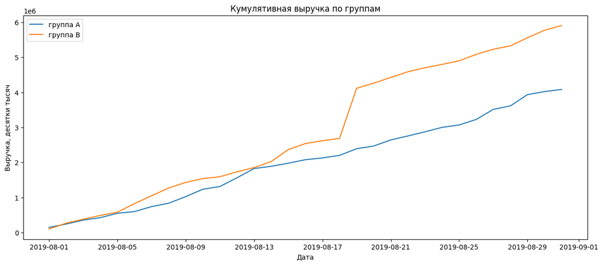

```python
#Получим данные по отдельно по группам
c_revenue_a = cumulative_table[cumulative_table['group']=='A'][['date','revenue', 'orders']]
c_revenue_b = cumulative_table[cumulative_table['group']=='B'][['date','revenue', 'orders']]

#Построим график кумулятивной выручки
plt.figure(figsize=(15,6))
plt.plot(c_revenue_a['date'], c_revenue_a['revenue'], label='группа A')
plt.plot(c_revenue_b['date'], c_revenue_b['revenue'], label='группа B')
plt.xlabel('Дата')
plt.ylabel('Выручка, десятки тысяч')
plt.title('Кумулятивная выручка по группам')
plt.legend();
```

В обеих группах отмечается стабильный рост выручки. Однако, во второй половине наблюдейний отмечается резкий прирост выручки в группе В. Такой всплеск может оказаться аномальных выбросом, чуть позже мы это проанализируем.

#### Разница среднего чека

К содержанию

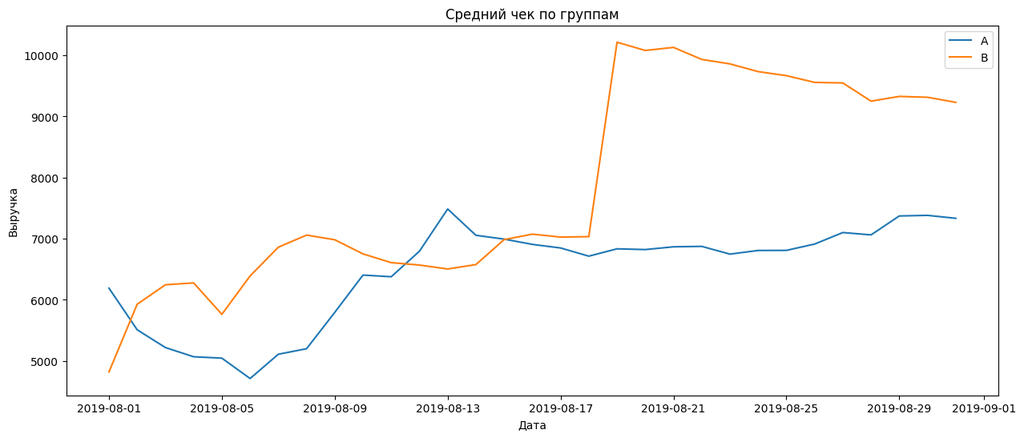

```python
plt.figure(figsize=(15,6))
plt.plot(c_revenue_a['date'], c_revenue_a['revenue']/c_revenue_a['orders'], label='A')
plt.plot(c_revenue_b['date'], c_revenue_b['revenue']/c_revenue_b['orders'], label='B')
plt.xlabel('Дата')
plt.ylabel('Выручка')
plt.title('Средний чек по группам')
plt.legend();
```

В первой половине теста отмечается уверенный рост среднего чека в группе В. Графики неравномерны в начале, средний чек группы А во второй половине теста стабилизировался, а вот в группе В мы снова можем заметить резкий всплеск.

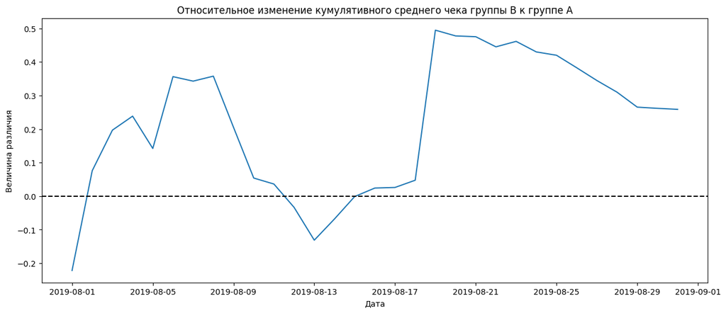

```python
с_revenue = c_revenue_a.merge(c_revenue_b,
                              left_on='date',
                              right_on='date',
                              how='left',
                              suffixes=['A', 'B'])

# cтроим отношение средних чеков
plt.figure(figsize=(15,6))
plt.plot(с_revenue['date'],
         (с_revenue['revenueB']/с_revenue['ordersB'])/(
             с_revenue['revenueA']/с_revenue['ordersA'])-1)
plt.xlabel('Дата')
plt.ylabel('Величина различия')
plt.title('Относительное изменение кумулятивного среднего чека группы В к группе А')

# добавляем ось X
plt.axhline(y=0, color='black', linestyle='--');
```

График относительного изменения неравномерный, отмечается несколько резких всплесков, возможно в эти даты происходили аномальные заказы.

#### Количество заказов на пользователя

К содержанию

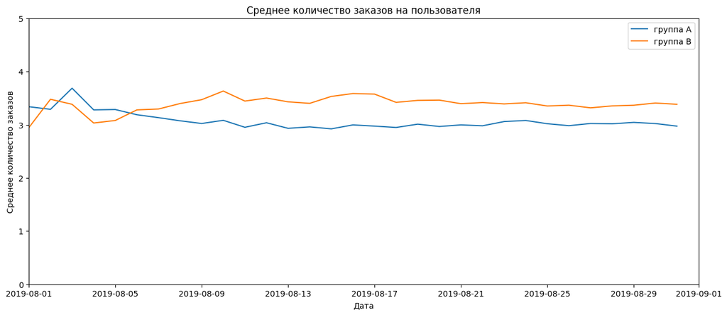

```python
#Добавим столбец с конверсией
cumulative_table['conversion'] = (cumulative_table['orders']/cumulative_table['visitors'])*100

# отделяем данные по группе A
c_conversion_a = cumulative_table[cumulative_table['group']=='A']

# отделяем данные по группе B
c_conversion_b = cumulative_table[cumulative_table['group']=='B']

# строим графики
plt.figure(figsize=(15,6))
plt.plot(c_conversion_a['date'], c_conversion_a['conversion'], label='группа A')
plt.plot(c_conversion_b['date'], c_conversion_b['conversion'], label='группа B')
plt.legend()
plt.xlabel('Дата')
plt.ylabel('Среднее количество заказов')
plt.title('Среднее количество заказов на пользователя')

# задаем масштаб осей
plt.axis([dt.datetime(2019, 8, 1), dt.datetime(2019, 9, 1), 0, 5]);
```

В начале наблюдений (первые 5-6 дней) отмечаются колебания среднего числа заказов пользователей. Далее значение держится относительно стабильно, и пользователи группы В охотнее совершают покупки, а вот в группе А наблюдается небольшое снижение среднего числа покупок.

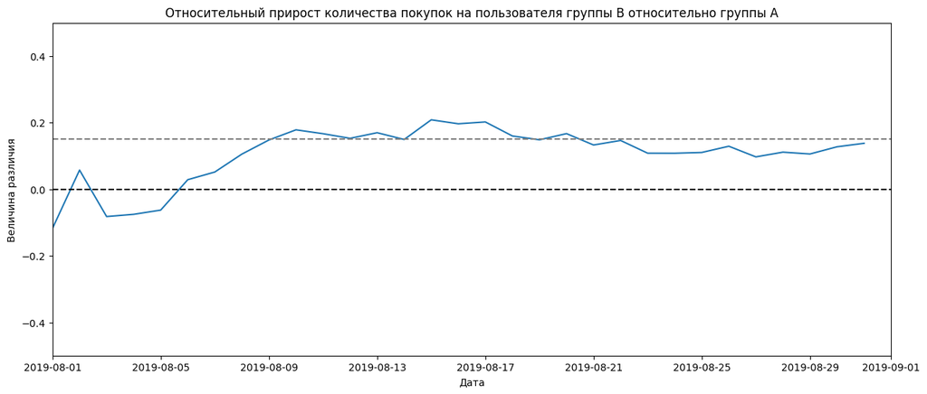

```python
с_conversion = c_conversion_a[['date','conversion']].merge(c_conversion_b[['date','conversion']],
                                                           left_on='date',
                                                           right_on='date',
                                                           how='left',
                                                           suffixes=['A', 'B'])

plt.figure(figsize=(15,6))
plt.plot(с_conversion['date'], с_conversion['conversionB']/с_conversion['conversionA']-1)
plt.xlabel('Дата')
plt.ylabel('Величина различия')
plt.title('Относительный прирост количества покупок на пользователя группы B относительно группы A')

plt.axhline(y=0, color='black', linestyle='--')
plt.axhline(y=0.15, color='grey', linestyle='--')
plt.axis([dt.datetime(2019, 8, 1), dt.datetime(2019, 9, 1), -0.5, 0.5]);
```

Прирост среднего количества заказов группы В составляет около 15% относительно группы А. Ближе к концу исследования прирост несколько снизился, но тенденции к падению до уровня группы А не наблюдается.

### Проверка наличия выбросов и всплесков

К содержанию

Исходя из анализа стабильности изучаемых метрик, можно сделать вывод, что в данные закрались выбросы. Стоит проверить какие выбросы и где, и провести анализ на отфильтрованных данных.

#### Количество заказов

К содержанию

Для начала проверим количество заказов и выберем границы отсечки для фильтрации данных.

```
count    1031.000000
mean        1.161009
std         0.724919
min         1.000000
25%         1.000000
50%         1.000000
75%         1.000000
max        11.000000
Name: orders, dtype: float64
```

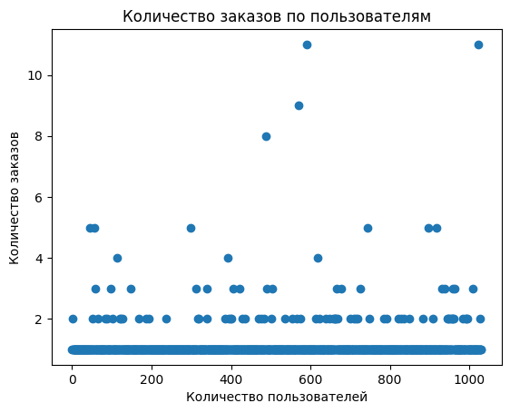

```python
orders_by_users = (
    orders.groupby('visitorId', as_index=False)
    .agg({'transactionId': 'nunique'})
)
orders_by_users.columns = ['user_id', 'orders']

print(orders_by_users['orders'].describe())
x_values = pd.Series(range(0, len(orders_by_users)))
plt.scatter(x_values, orders_by_users['orders'])
plt.xlabel('Количество пользователей')
plt.ylabel('Количество заказов')
plt.title('Количество заказов по пользователям');
```

Согласно точечному графику распределения пользователи совершают не более двух заказов. Максимальное количество заказов составляет 11 - неожиданно много, но все бывает.

Теперь оценим сколько заказов совершает большинство пользователей.

```python
np.percentile(orders_by_users['orders'], [95, 99])
```

```
array([2., 4.])
```

Проанализировав процентили, мы определили, что только 5% пользователей совершают более 2 заказов. Значит в качестве "нормального" значения возьмем два заказа.

#### Стоимость заказов

К содержанию

Теперь оценим, насколько дорогие совершаются заказы.

```
count    1.197000e+03
mean     8.348006e+03
std      3.919113e+04
min      5.000000e+01
25%      1.220000e+03
50%      2.978000e+03
75%      8.290000e+03
max      1.294500e+06
Name: revenue, dtype: float64
```

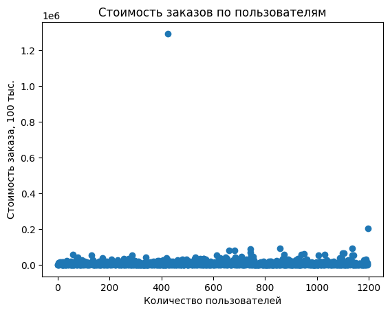

```python
print(orders['revenue'].describe())
x_values = pd.Series(range(0, len(orders['revenue'])))
plt.scatter(x_values, orders['revenue'])
plt.xlabel('Количество пользователей')
plt.ylabel('Стоимость заказа, 100 тыс.')
plt.title('Стоимость заказов по пользователям');
```

Похоже, что основная часть зказов не превышает 20 тысяч. Самый дорогой заказ стоит более 1 миллиона.

```python
np.percentile(orders['revenue'], [95, 99])
```

```
array([28000. , 58233.2])
```

Действительно, только 5 процентов пользователей делают заказы на сумму более 28000, и только один процент пользователей оплачивает заказ более чем на 58000.

Таким образом, мы возьмем отсечку пользователей, которые совершили `2` заказа и меньше, на сумму не более `28000`.

### Статистическая значимость различий

К содержанию

Для того, чтобы оценить различия между двумя исследуемыми группами, а также значимость различий, в случае, если они есть, протестируем следующие гипотезы:

- Н0(нулевая гипотеза): Средние значения метрик группы А и В равны, различия статистически не значимы;
- Н1(альтернативная гипотеза): Средние значения метрик группы А и В не равны, различия статистически значимы.

Производить проверку гипотез мы будем с использованием теста Уилкоксона-Манна-Уитни, так как наше исследование касается поведенческих особенностей человека, и оно плохо подходит под нормальное распределение.

#### На "сырых" данных

К содержанию

```python
#Соберем визиты по группам
visitors_by_day_a = visitors[visitors['group'] == 'A'][['date', 'visitors']]
visitors_by_day_a.columns = ['date', 'a_visitors']

c_visitors_a = visitors_by_day_a.apply(
    lambda x: visitors_by_day_a[visitors_by_day_a['date'] <= x['date']].agg(
        {'date': 'max', 'a_visitors': 'sum'}
    ),axis=1)

c_visitors_a.columns = ['date', 'c_a_visitors']

visitors_by_day_b = visitors[visitors['group'] == 'B'][['date', 'visitors']]
visitors_by_day_b.columns = ['date', 'b_visitors']

c_visitors_b = visitors_by_day_b.apply(
    lambda x: visitors_by_day_b[visitors_by_day_b['date'] <= x['date']].agg(
        {'date': 'max', 'b_visitors': 'sum'}
    ),
    axis=1,
)
c_visitors_b.columns = ['date', 'c_b_visitors']


#Соберем заказы по группам
orders_by_day_a = (
    orders[orders['group'] == 'A'][['date', 'transactionId', 'visitorId', 'revenue']]
    .groupby('date', as_index=False)
    .agg({'transactionId': pd.Series.nunique, 'revenue': 'sum'})
)
orders_by_day_a.columns = ['date', 'a_orders', 'a_revenue']

c_orders_a = orders_by_day_a.apply(
    lambda x: orders_by_day_a[orders_by_day_a['date'] <= x['date']].agg(
        {'date': 'max', 'a_orders': 'sum', 'a_revenue': 'sum'}
    ),axis=1).sort_values(by=['date'])

c_orders_a.columns = ['date','c_orders_a','c_revenue_a']

orders_by_day_b = (
    orders[orders['group'] == 'B'][['date', 'transactionId', 'visitorId', 'revenue']]
    .groupby('date', as_index=False)
    .agg({'transactionId': pd.Series.nunique, 'revenue': 'sum'})
)
orders_by_day_b.columns = ['date', 'b_orders', 'b_revenue']

c_orders_b = orders_by_day_b.apply(
    lambda x: orders_by_day_b[orders_by_day_b['date'] <= x['date']].agg(
        {'date': 'max', 'b_orders': 'sum', 'b_revenue': 'sum'}
    ),axis=1).sort_values(by=['date'])

c_orders_b.columns = ['date','c_orders_b','c_revenue_b']

#Получим общую таблицу для работы
data = (
    orders_by_day_a.merge(orders_by_day_b, left_on='date', right_on='date', how='left')
    .merge(c_orders_a, left_on='date', right_on='date', how='left')
    .merge(c_orders_b, left_on='date', right_on='date', how='left')
    .merge(visitors_by_day_a, left_on='date', right_on='date', how='left')
    .merge(visitors_by_day_b, left_on='date', right_on='date', how='left')
    .merge(c_visitors_a, left_on='date', right_on='date', how='left')
    .merge(c_visitors_b, left_on='date', right_on='date', how='left')
)


#Для каждой группы создадим таблицы, содержащие количество заказов для каждого пользователя
orders_users_a = (orders[orders['group'] == 'A'].groupby('visitorId', as_index=False)
                  .agg({'transactionId': pd.Series.nunique}))
orders_users_a.columns = ['user_id', 'orders']

orders_users_b = (orders[orders['group'] == 'B'].groupby('visitorId', as_index=False)
                  .agg({'transactionId': pd.Series.nunique}))
orders_users_b.columns = ['user_id', 'orders']

data_a = pd.concat(
    [orders_users_a['orders'],
     pd.Series(0,index=np.arange(data['a_visitors'].sum() - len(orders_users_a['orders'])),
                                        name='orders')],axis=0)

data_b = pd.concat(
    [orders_users_b['orders'],
     pd.Series(0, index=np.arange(data['b_visitors'].sum() - len(orders_users_b['orders'])),
                                        name='orders')],axis=0)
```

```python
print('alpha =', 0.05)
print('p-value = {0:.3f}'.format(st.mannwhitneyu(data_a, data_b)[1]))
print('Относительный прирост числа заказов группы B по отношению к группе A: {0:.3f}'.format(
    (data['b_orders'].sum()/data['b_visitors'].sum())/
    (data['a_orders'].sum()/data['a_visitors'].sum())-1))
```

```
alpha = 0.05
p-value = 0.017
Относительный прирост числа заказов группы B по отношению к группе A: 0.138
```

Полученное значение p-value говорит о том, что различия между группами есть и они статистически значимы. Значит, мы можем отвергнуть нулевую гипотезу. Число заказов на человека группы В больше на 13.8%, посмотрим, будет ли разница у отфильтрованных данных.

```python
print('alpha =', 0.05)
print('p_value = {0:.3f}'.format(st.mannwhitneyu(orders[orders['group']=='A']['revenue'],
                                       orders[orders['group']=='B']['revenue'])[1]))
print('Относительное изменение среднего чека в группе B по отношению группы A: {0:.3f}'.format(
    orders[orders['group']=='B']['revenue'].mean()/
    orders[orders['group']=='A']['revenue'].mean()-1))
```

```
alpha = 0.05
p_value = 0.729
Относительное изменение среднего чека в группе B по отношению группы A: 0.259
```

Средний чек в группе В отличается почти на 25%, однако, согласно значению p-value это отличие не имеет статистической значимости. Мы не можем отвергнуть нулевую гипотезу - средний чек группы В не отличается от среднего чека группы А.

#### На "очищенных" данных

К содержанию

```python
#Определим пользователей, которые сделали аномально много заказов
many_orders = pd.concat(
    [orders_users_a[orders_users_a['orders'] > 2]['user_id'],
     orders_users_b[orders_users_b['orders'] > 2]['user_id']],
    axis=0,)

#Определим id пользователей со слишком дорогими покупками
expensive_orders = orders[orders['revenue'] > 28000]['visitorId']

#Получим датафрейм с пользователями, которые нам не подходят из-за выбросов
anomalies = (pd.concat([many_orders, expensive_orders], axis=0)
               .drop_duplicates()
               .sort_values())


#Отфильтруем наши доли, исключив пользователей с аномальными заказами
filtered_data_a = pd.concat(
    [orders_users_a[np.logical_not(orders_users_a['user_id'].isin(anomalies))]['orders'],
        pd.Series(0, index=np.arange(
                data['a_visitors'].sum() - len(orders_users_a['orders'])),
        name='orders')], axis=0)

filtered_data_b = pd.concat(
    [orders_users_b[np.logical_not(orders_users_b['user_id'].isin(anomalies))]['orders'],
        pd.Series(0,index=np.arange(
                data['b_visitors'].sum() - len(orders_users_b['orders'])),
            name='orders')], axis=0)
```

```python
print('alpha =', 0.05)
print('p-value = {0:.3f}'.format(st.mannwhitneyu(filtered_data_a, filtered_data_b)[1]))
print('Относительный прирост числа заказов группы B по отношению к группе A: {0:.3f}'.format(
    filtered_data_b.mean()/filtered_data_a.mean()-1))
```

```
alpha = 0.05
p-value = 0.013
Относительный прирост числа заказов группы B по отношению к группе A: 0.173
```

А вот после "очистки" данных выяснилось, что различия в числе заказов на пользователя даже больше, но они также значимы.

```python
print('alpha =', 0.05)
print('p-value = {0:.3f}'.format(
        st.mannwhitneyu(
            orders[np.logical_and(
                    orders['group'] == 'A',
                    np.logical_not(orders['visitorId'].isin(anomalies)))]['revenue'],
            orders[np.logical_and(
                    orders['group'] == 'B',
                    np.logical_not(orders['visitorId'].isin(anomalies)))]['revenue'])[1]))

print('Относительное изменение среднего чека в группе B по отношению группы A: {0:.3f}'.format(
        orders[np.logical_and(
                orders['group'] == 'B',
                np.logical_not(orders['visitorId'].isin(anomalies)))]['revenue'].mean()
        / orders[np.logical_and(
                orders['group'] == 'A',
                np.logical_not(orders['visitorId'].isin(anomalies)))]['revenue'].mean()- 1))
```

```
alpha = 0.05
p-value = 0.738
Относительное изменение среднего чека в группе B по отношению группы A: -0.020
```

По среднему чеку группы не различаются, и группа В даже немного "отстаёт". Но это не имеет сильного значения, так как p-value слишком велик.

## Вывод

К содержанию

В течение августа 2019 года проводилось А/В-тестирование. Мы провели анализ полученных результатов и сделали следующие выводы:

- Конверсия пользователей в группе В превышает конверсию в группе А на 17% при анализе данных без аномальных выбросов.
- Прирост конверсии имеет статичтисескую значимость.
- Разница между средними чеками не имеет статистического значения.